# Quantified Self Movement: Classification of Form

Damon Grummet

28 February 2016

## Preface

The prevalence of movement monitoring functionality in mobile devices has led to cheaper and easier analysis of various movement behaviors. The research team at 'groupware@LES‘(’http://groupware.les.inf.puc-rio.br/’) have been studying this field, and they have kindly provided access to their ‘Weight Lifting Exercises’ data-set (‘http://groupware.les.inf.puc-rio.br/har’) for learning exercises.

The Weight Lifting Exercises data-set provides accelerometer data measurements of 5 subjects who were tasked with lifting weights following the ‘Unilateral Dumbbell Biceps Curl’, specifically performing the exercise correctly (1 class) and incorrectly (4 classes) to provide data for attempting to generate algorithms to classify the movements automatically.

This document is this author’s attempt to select an acceptable classification algorithm using standard machine-learning methods, as taught in the associated course ‘Practical Machine Learning’, a MOOC made available via Coursera.

The following sections outline data exploration, preprocessing, model fitting and selection, using customised training and testing data-sets provided via the class assignment.

## Data Analysis and Preprocessing

The provided data was loaded into two raw sets, downloaded as train.csv and test.csv. An initial review of the data showed that there were two distinct data-sets present within the training file - raw readings from each subject, and summary lines showing the statistical summary for each set of raw readings. As we only want to work with the raw data, only the following subset of data was retained:

```r
rawtrainData <- read.csv("train.csv")
rawtestData <- read.csv("test.csv")
#data cleansing
# through raw data observation of the trainData set, there are 19216 records (of 19622)
# where a large number of variables are either blank or '#DIV/0!'
#
# Also, there are two types of observations in the data, indicated by the value
# of variable 'new_window' - where it is 'yes' summary data is shown, for the columns
# such as max_roll_belt, min_pitch_arm and so on.
# As these are summary computed data, we will exclude them, along with all the columns
# that store only those values.
# We also have no interest in the timestamp, the window number, or ....
# In fact, we are only interested in the raw accelerometer movements for prediction.

trainData <- sqldf('select roll_belt,
                    pitch_belt,
                   yaw_belt,
                   total_accel_belt,
                   gyros_belt_x,
                   gyros_belt_y,
                   gyros_belt_z,
                   accel_belt_x,
                   accel_belt_y,
                   accel_belt_z,
                   magnet_belt_x,
                   magnet_belt_y,
                   magnet_belt_z,
                   roll_arm,
                   pitch_arm,
                   yaw_arm,
                   total_accel_arm,
                   gyros_arm_x,
                   gyros_arm_y,
                   gyros_arm_z,
                   accel_arm_x,
                   accel_arm_y,
                   accel_arm_z,
                   magnet_arm_x,
                   magnet_arm_y,
                   magnet_arm_z,
                   roll_dumbbell,
                   pitch_dumbbell,
                   yaw_dumbbell,
                   total_accel_dumbbell,
                   gyros_dumbbell_x,
                   gyros_dumbbell_y,
                   gyros_dumbbell_z,
                   accel_dumbbell_x,
                   accel_dumbbell_y,
                   accel_dumbbell_z,
                   magnet_dumbbell_x,
                   magnet_dumbbell_y,
                   magnet_dumbbell_z,
                   roll_forearm,
                   pitch_forearm,
                   yaw_forearm,
                   total_accel_forearm,
                   gyros_forearm_x,
                   gyros_forearm_y,
                   gyros_forearm_z,
                   accel_forearm_x,
                   accel_forearm_y,
                   accel_forearm_z,
                   magnet_forearm_x,
                   magnet_forearm_y,
                   magnet_forearm_z,
                   classe
                   from rawtrainData
                   where new_window = "no"')
```

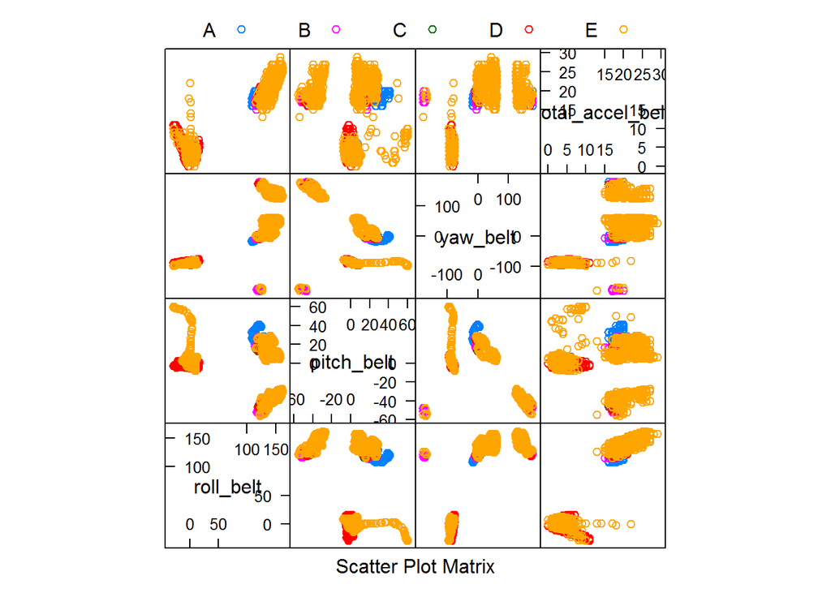

```r
#feature plot example, suggesting there are three distinct patterns of data
# (in keeping with intuition of the exercise movements likely)(also a relation to the
# num_window variable, which has been omitted from the training data as it is not
# constructive to the prediction exercise)
featurePlot(trainData[,1:4], as.factor(trainData$classe), plot="pairs", auto.key = list(columns=5))
```

The outcome variable in the data is called ‘classe’, and is a categorical factor with five levels marked ‘A’ through ‘E’. It is unknown which of these categories represents a correct form (information not provided in assignment notes).

The data can be visualised in 3 dimensions, showing a pattern that is suggestive of the actual movement of lifting a weight in a bicep curl:

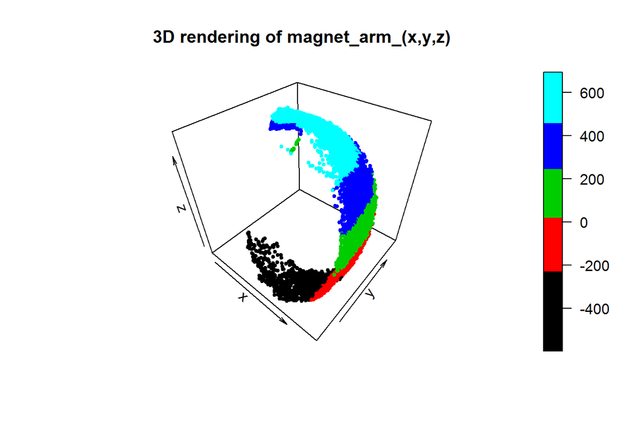

Next is a check for limited variance in any of the variables. If the variance is near zero, the variable should be omitted. However in this data-set no variables have near-zero variance.

```r
#Check for feature variance - anything close to zero should be omitted:
nearZeroVar(trainData, saveMetrics=TRUE)
```

```
##                      freqRatio percentUnique zeroVar   nzv
## roll_belt             1.086168    6.83805162   FALSE FALSE
## pitch_belt            1.036649    9.53892590   FALSE FALSE
## yaw_belt              1.047244   10.10616153   FALSE FALSE
## total_accel_belt      1.069434    0.15091590   FALSE FALSE
## gyros_belt_x          1.050784    0.72335554   FALSE FALSE
## gyros_belt_y          1.148947    0.35907577   FALSE FALSE
## gyros_belt_z          1.071098    0.87947544   FALSE FALSE
## accel_belt_x          1.059367    0.85345545   FALSE FALSE
## accel_belt_y          1.115333    0.74417152   FALSE FALSE
## accel_belt_z          1.080702    1.55599500   FALSE FALSE
## magnet_belt_x         1.089080    1.70170691   FALSE FALSE
## magnet_belt_y         1.096519    1.55079101   FALSE FALSE
## magnet_belt_z         1.019481    2.37302248   FALSE FALSE
## roll_arm             51.153846   13.75936719   FALSE FALSE
## pitch_arm            85.282051   15.96065779   FALSE FALSE
## yaw_arm              32.281553   14.89904246   FALSE FALSE
## total_accel_arm       1.020316    0.34346378   FALSE FALSE
## gyros_arm_x           1.023715    3.34616986   FALSE FALSE
## gyros_arm_y           1.450593    1.95149875   FALSE FALSE
## gyros_arm_z           1.118908    1.29059117   FALSE FALSE
## accel_arm_x           1.017751    4.04350541   FALSE FALSE
## accel_arm_y           1.169082    2.78413822   FALSE FALSE
## accel_arm_z           1.139344    4.12156536   FALSE FALSE
## magnet_arm_x          1.011765    6.96294754   FALSE FALSE
## magnet_arm_y          1.045455    4.53268110   FALSE FALSE
## magnet_arm_z          1.027778    6.57785179   FALSE FALSE
## roll_dumbbell         1.037879   84.17464613   FALSE FALSE
## pitch_dumbbell        2.248175   81.73397169   FALSE FALSE
## yaw_dumbbell          1.132231   83.34721066   FALSE FALSE
## total_accel_dumbbell  1.081020    0.22377186   FALSE FALSE
## gyros_dumbbell_x      1.010050    1.25416320   FALSE FALSE
## gyros_dumbbell_y      1.270979    1.44150708   FALSE FALSE
## gyros_dumbbell_z      1.052632    1.06681932   FALSE FALSE
## accel_dumbbell_x      1.006061    2.21169858   FALSE FALSE
## accel_dumbbell_y      1.062500    2.41985845   FALSE FALSE
## accel_dumbbell_z      1.150215    2.12323064   FALSE FALSE
## magnet_dumbbell_x     1.093567    5.84929226   FALSE FALSE
## magnet_dumbbell_y     1.188571    4.38176520   FALSE FALSE
## magnet_dumbbell_z     1.026596    3.51269775   FALSE FALSE
## roll_forearm         11.726154   11.23542881   FALSE FALSE
## pitch_forearm        64.576271   15.09679434   FALSE FALSE
## yaw_forearm          15.236000   10.29870941   FALSE FALSE
## total_accel_forearm   1.132729    0.36427977   FALSE FALSE
## gyros_forearm_x       1.050193    1.54558701   FALSE FALSE
## gyros_forearm_y       1.043011    3.84054954   FALSE FALSE
## gyros_forearm_z       1.112051    1.58201499   FALSE FALSE
## accel_forearm_x       1.142857    4.13197336   FALSE FALSE
## accel_forearm_y       1.050000    5.20920067   FALSE FALSE
## accel_forearm_z       1.019231    3.01311407   FALSE FALSE
## magnet_forearm_x      1.012658    7.92568693   FALSE FALSE
## magnet_forearm_y      1.256410    9.72626978   FALSE FALSE
## magnet_forearm_z      1.017544    8.75832639   FALSE FALSE
## classe                1.471490    0.02601998   FALSE FALSE
```

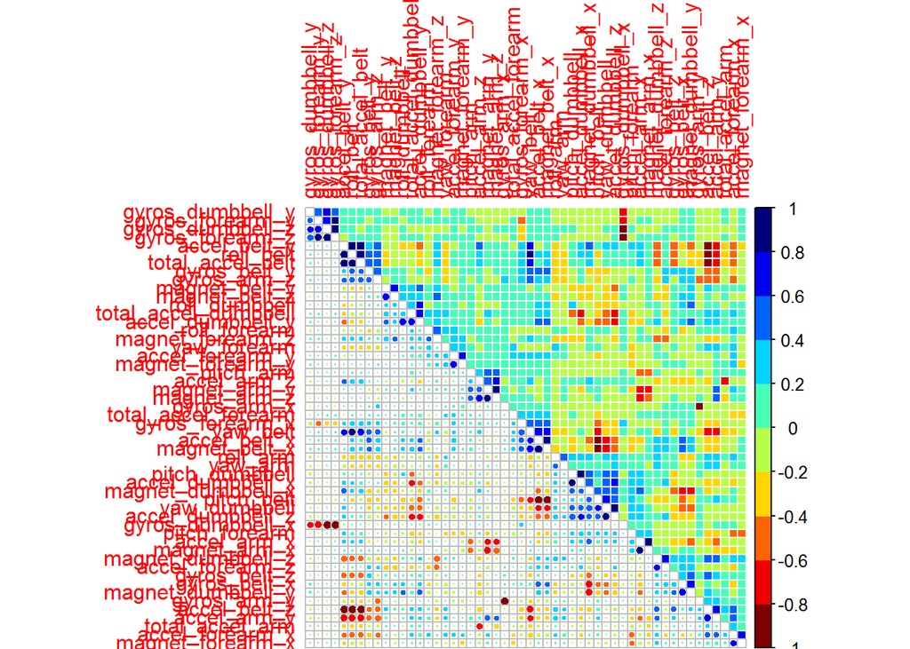

Before generating model fit, the data needs to be centered and normalized, and split into subsets for training and validation (70/30):

```r
#center and normalize data
preProcObj <- preProcess(trainData[, -53],method=c("center","scale"))

trainData <- cbind(predict(preProcObj, trainData[, -53]),classe=trainData[,53])

# need a fit training and testing set, so split the data 70/30:
inTrain <- createDataPartition(y=trainData$classe,p=0.7, list=FALSE)
training <- trainData[inTrain,]
testing <- trainData[-inTrain,]
```

## Model Fitting and Selection

Due to the nature of the exercise, being classification into one of five categories, and the data being multidimensional in nature with a large number of potentially significant features, a linear model would require significant re-factoring to fit. Instead, the major machine-learning algorithms of Trees, Random Forests (RF), and Generalized Boosting Regression (GBM) will be used and tested.

Note, given there are under 20,000 observations in the raw training data, splitting the data (as done here to provide a validation set) is likely to negatively impact the accuracy of the model training. Hence, a cross-validation method needs to be employed to mitigate loss of accuracy. Here we use 10 folds for all the models.

```r
# using 10-fold Cross-Validation
fitControl <- trainControl(method="cv",
                           number=10,
                           verboseIter=FALSE,
                           allowParallel=TRUE)

#tree model (for comparison):
fittree <- train(classe~.,data=training,method="rpart", trControl=fitControl, preProcess=c("pca"))
fittree$finalModel
```

```
## n= 13453
##
## node), split, n, loss, yval, (yprob)
##       * denotes terminal node
##
## 1) root 13453 9623 A (0.28 0.19 0.17 0.16 0.18)
##   2) PC15< 1.14011 12376 8576 A (0.31 0.2 0.19 0.17 0.14)
##     4) PC3< 0.5983483 7879 4817 A (0.39 0.16 0.21 0.14 0.1) *
##     5) PC3>=0.5983483 4497 3316 B (0.16 0.26 0.15 0.21 0.21) *
##   3) PC15>=1.14011 1077  361 E (0.028 0.15 0.029 0.13 0.66) *
```

```r
treePred <- predict(fittree,testing)
confusionMatrix(testing$classe,treePred)
```

```
## Confusion Matrix and Statistics
##
##           Reference
## Prediction    A    B    C    D    E
##          A 1314  313    0    0   14
##          B  575  479    0    0   61
##          C  676  317    0    0   12
##          D  473  408    0    0   63
##          E  397  388    0    0  273
##
## Overall Statistics
##
##                Accuracy : 0.3585
##                  95% CI : (0.3461, 0.371)
##     No Information Rate : 0.596
##     P-Value [Acc > NIR] : 1
##
##                   Kappa : 0.1479
##  Mcnemar's Test P-Value : NA
##
## Statistics by Class:
##
##                      Class: A Class: B Class: C Class: D Class: E
## Sensitivity            0.3825  0.25144       NA       NA  0.64539
## Specificity            0.8595  0.83515   0.8256   0.8362  0.85300
## Pos Pred Value         0.8007  0.42960       NA       NA  0.25803
## Neg Pred Value         0.4854  0.69320       NA       NA  0.96812
## Prevalence             0.5960  0.33056   0.0000   0.0000  0.07340
## Detection Rate         0.2280  0.08312   0.0000   0.0000  0.04737
## Detection Prevalence   0.2847  0.19348   0.1744   0.1638  0.18358
## Balanced Accuracy      0.6210  0.54330       NA       NA  0.74919
```

```r
#Parallel Random Forest:
suppressWarnings(
fitRFpar <- train(classe~.,data=training,method="parRF", trControl=fitControl, preProcess=c("pca"))
)
predRFpar <- predict(fitRFpar,testing)
confusionMatrix(testing$classe,predRFpar)
```

```
## Confusion Matrix and Statistics
##
##           Reference
## Prediction    A    B    C    D    E
##          A 1631    5    3    1    1
##          B   13 1076   22    4    0
##          C    3   22  961   14    5
##          D    1    1   45  897    0
##          E    1    5    9    4 1039
##
## Overall Statistics
##
##                Accuracy : 0.9724
##                  95% CI : (0.9678, 0.9765)
##     No Information Rate : 0.2861
##     P-Value [Acc > NIR] : < 2.2e-16
##
##                   Kappa : 0.9651
##  Mcnemar's Test P-Value : 0.0004346
##
## Statistics by Class:
##
##                      Class: A Class: B Class: C Class: D Class: E
## Sensitivity            0.9891   0.9702   0.9240   0.9750   0.9943
## Specificity            0.9976   0.9916   0.9907   0.9903   0.9960
## Pos Pred Value         0.9939   0.9650   0.9562   0.9502   0.9820
## Neg Pred Value         0.9956   0.9929   0.9834   0.9952   0.9987
## Prevalence             0.2861   0.1924   0.1805   0.1596   0.1813
## Detection Rate         0.2830   0.1867   0.1668   0.1556   0.1803
## Detection Prevalence   0.2847   0.1935   0.1744   0.1638   0.1836
## Balanced Accuracy      0.9933   0.9809   0.9574   0.9826   0.9951
```

```r
#Bagging with trees
fitGBM <- train(classe ~ ., method="gbm",data=training,trControl=fitControl,verbose=FALSE, preProcess=c("pca"))
predGBM <- predict(fitGBM,testing)
confusionMatrix(testing$classe,predGBM)
```

```
## Confusion Matrix and Statistics
##
##           Reference
## Prediction    A    B    C    D    E
##          A 1474   43   34   67   23
##          B  133  818  100   17   47
##          C   57   69  821   47   11
##          D   48   35  104  733   24
##          E   32   86   86   56  798
##
## Overall Statistics
##
##                Accuracy : 0.8058
##                  95% CI : (0.7954, 0.816)
##     No Information Rate : 0.3026
##     P-Value [Acc > NIR] : < 2.2e-16
##
##                   Kappa : 0.7539
##  Mcnemar's Test P-Value : < 2.2e-16
##
## Statistics by Class:
##
##                      Class: A Class: B Class: C Class: D Class: E
## Sensitivity            0.8452   0.7783   0.7170   0.7967   0.8837
## Specificity            0.9584   0.9370   0.9602   0.9564   0.9465
## Pos Pred Value         0.8982   0.7336   0.8169   0.7765   0.7543
## Neg Pred Value         0.9345   0.9499   0.9319   0.9612   0.9777
## Prevalence             0.3026   0.1824   0.1987   0.1596   0.1567
## Detection Rate         0.2558   0.1419   0.1425   0.1272   0.1385
## Detection Prevalence   0.2847   0.1935   0.1744   0.1638   0.1836
## Balanced Accuracy      0.9018   0.8576   0.8386   0.8766   0.9151
```

Comparing the three chosen models gives the following summary and chart:

```r
#Model Fittness and Selection

# collect resamples
results = resamples(list(GBM=fitGBM, RandomForest=fitRFpar, Tree=fittree))

# summarize the distributions
summary(results)
```

```
##
## Call:
## summary.resamples(object = results)
##
## Models: GBM, RandomForest, Tree
## Number of resamples: 10
##
## Accuracy
##                Min. 1st Qu. Median   Mean 3rd Qu.   Max. NA's
## GBM          0.7970  0.8043 0.8134 0.8129  0.8204 0.8299    0
## RandomForest 0.9643  0.9686 0.9729 0.9734  0.9773 0.9829    0
## Tree         0.3371  0.3524 0.3628 0.3595  0.3704 0.3722    0
##
## Kappa
##                 Min. 1st Qu. Median   Mean 3rd Qu.   Max. NA's
## GBM          0.74280  0.7517 0.7632 0.7628  0.7725 0.7842    0
## RandomForest 0.95490  0.9603 0.9657 0.9663  0.9713 0.9784    0
## Tree         0.08317  0.1410 0.1554 0.1442  0.1672 0.1689    0
```

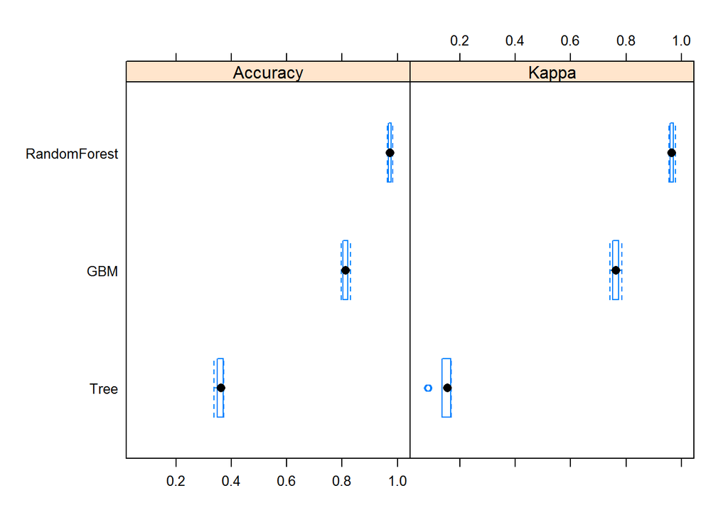

```r
# boxplots of results
bwplot(results)
```

## Conclusion

For the given training data, the Random Forest model has demonstrated the highest accuracy rate of 97% for correct classification of exercise method used.

This model can now be used to predict the categories of the provided test data-set, as follows:

```r
#Apply prediction model to test data
testData <- sqldf('select user_name,
                    roll_belt,
                    pitch_belt,
                   yaw_belt,
                   total_accel_belt,
                   gyros_belt_x,
                   gyros_belt_y,
                   gyros_belt_z,
                   accel_belt_x,
                   accel_belt_y,
                   accel_belt_z,
                   magnet_belt_x,
                   magnet_belt_y,
                   magnet_belt_z,
                   roll_arm,
                   pitch_arm,
                   yaw_arm,
                   total_accel_arm,
                   gyros_arm_x,
                   gyros_arm_y,
                   gyros_arm_z,
                   accel_arm_x,
                   accel_arm_y,
                   accel_arm_z,
                   magnet_arm_x,
                   magnet_arm_y,
                   magnet_arm_z,
                   roll_dumbbell,
                   pitch_dumbbell,
                   yaw_dumbbell,
                   total_accel_dumbbell,
                   gyros_dumbbell_x,
                   gyros_dumbbell_y,
                   gyros_dumbbell_z,
                   accel_dumbbell_x,
                   accel_dumbbell_y,
                   accel_dumbbell_z,
                   magnet_dumbbell_x,
                   magnet_dumbbell_y,
                   magnet_dumbbell_z,
                   roll_forearm,
                   pitch_forearm,
                   yaw_forearm,
                   total_accel_forearm,
                   gyros_forearm_x,
                   gyros_forearm_y,
                   gyros_forearm_z,
                   accel_forearm_x,
                   accel_forearm_y,
                   accel_forearm_z,
                   magnet_forearm_x,
                   magnet_forearm_y,
                   magnet_forearm_z
                   from rawtestData
                   where new_window = "no"')

#remember to apply the preprocessing and PCA analysis in preProcObj:
answers = predict(fitRFpar, newdata=predict(preProcObj,testData))
```